# Histopathologic Cancer Detection with CNN

## Binary classification of metastatic cancer in tissue samples

```python
import cv2
import numpy as np
import pandas as pd
import matplotlib.pyplot as plt
from scipy import stats
import seaborn as sns
from sklearn.model_selection import train_test_split
from sklearn.metrics import roc_auc_score, confusion_matrix, classification_report
from sklearn.utils import shuffle

import tensorflow as tf
from tensorflow import keras
from tensorflow.keras.models import load_model, Sequential
from tensorflow.keras.layers import Conv2D, MaxPooling2D, Flatten, Dense, Dropout, BatchNormalization
from tensorflow.keras.preprocessing.image import ImageDataGenerator
from tensorflow.keras.callbacks import EarlyStopping, ReduceLROnPlateau, ModelCheckpoint, CSVLogger
from tensorflow.keras.regularizers import l1, l2, l1_l2

import os
from PIL import Image
from tqdm import tqdm

# Set random seeds for reproducibility
np.random.seed(42)
tf.random.set_seed(42)
```

```
2025-09-10 10:43:25.735520: I tensorflow/core/platform/cpu_feature_guard.cc:210] This TensorFlow binary is optimized to use available CPU instructions in performance-critical operations.
To enable the following instructions: AVX2 FMA, in other operations, rebuild TensorFlow with the appropriate compiler flags.
```

## Problem Description: Histopathologic Cancer Detection

This project addresses the binary classification task of detecting metastatic cancer in small image patches taken from larger digital pathology scans. The dataset consists of 96x96 pixel RGB images extracted from histopathologic scans of lymph node sections. The size is convenient: bigger than CIFAR10, smaller than imagenet, trainable on a single GPU.

The challenge originates from the [PatchCamelyon (PCam) benchmark dataset](https://github.com/basveeling/pcam), which provides a realistic simulation of the task pathologists face when examining lymph node sections for metastatic cancer. Lymph node involvement is clinically crucial for cancer staging and treatment decisions, as the presence of metastasis significantly impacts patient prognosis and therapeutic approaches.

Data source: [Kaggle](https://www.kaggle.com/competitions/histopathologic-cancer-detection/).

```python
# Configuration
DATA_DIR = '/kaggle/input/histopathologic-cancer-detection' if 'KAGGLE_URL_BASE' in os.environ else 'data_3'
TRAIN_DIR = os.path.join(DATA_DIR, 'train')
TEST_DIR = os.path.join(DATA_DIR, 'test')

IMG_SIZE = 96
BATCH_SIZE = 64
EPOCHS = 30
```

```python
# Load and explore the data
train_labels = pd.read_csv(os.path.join(DATA_DIR, 'train_labels.csv'))

# Inspect the data
display(train_labels.head())
train_labels.info()

# Add full paths to the dataframe
train_labels['path'] = train_labels['id'].apply(lambda img_id: os.path.join(TRAIN_DIR, f"{img_id}.tif"))
```

|  | id | label |
| --- | --- | --- |
| 0 | f38a6374c348f90b587e046aac6079959adf3835 | 0 |
| 1 | c18f2d887b7ae4f6742ee445113fa1aef383ed77 | 1 |
| 2 | 755db6279dae599ebb4d39a9123cce439965282d | 0 |
| 3 | bc3f0c64fb968ff4a8bd33af6971ecae77c75e08 | 0 |
| 4 | 068aba587a4950175d04c680d38943fd488d6a9d | 0 |

```
<class 'pandas.core.frame.DataFrame'>
RangeIndex: 220025 entries, 0 to 220024
Data columns (total 2 columns):
 #   Column  Non-Null Count   Dtype
---  ------  --------------   -----
 0   id      220025 non-null  object
 1   label   220025 non-null  int64
dtypes: int64(1), object(1)
memory usage: 3.4+ MB
```

## Comprehensive Exploratory Data Analysis (EDA)

```python
# Check for missing values
print("Missing values in labels:", train_labels.isnull().sum().sum())
print("Duplicate IDs:", train_labels['id'].duplicated().sum())
```

```
Missing values in labels: 0
Duplicate IDs: 0
```

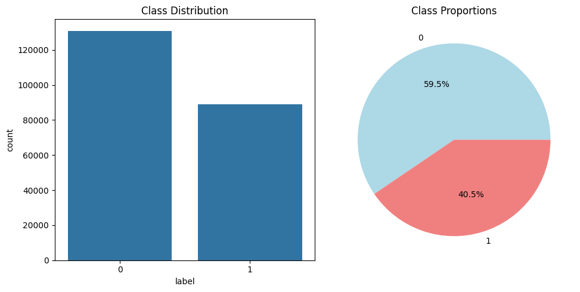

```python
# Visualize class distribution
plt.figure(figsize=(10, 5))
plt.subplot(1, 2, 1)
sns.countplot(x='label', data=train_labels)
plt.title('Class Distribution')

plt.subplot(1, 2, 2)
plt.pie(train_labels['label'].value_counts(),
        labels=['0', '1'],
        autopct='%1.1f%%', colors=['lightblue', 'lightcoral'])
plt.title('Class Proportions')
plt.tight_layout()
plt.show()
```

```python
# Image metadata analysis
def analyze_image_metadata(df, sample_size=1000):
    """Analyze image dimensions, formats, and basic statistics"""
    print("Analysis done on a sample of %d images" % sample_size)

    # Sample images for analysis
    sample_df = df.sample(min(sample_size, len(df)), random_state=42)

    dimensions = []
    formats = []
    mean_intensities = []
    std_intensities = []

    for _, row in tqdm(sample_df.iterrows(), desc="Analyzing image metadata"):
        img = Image.open(row['path'])
        img_array = np.array(img)

        dimensions.append(img_array.shape)
        formats.append(img.format if img.format else 'Unknown')
        mean_intensities.append(np.mean(img_array))
        std_intensities.append(np.std(img_array))

    # Analyze dimensions
    unique_dims = set(dimensions)
    print("Unique image dimensions:", unique_dims)
    print("All images same size:", len(unique_dims) == 1)

    # Analyze formats
    print("All images have a format of %s:" % formats[0], all(map(lambda x: x == formats[0], formats)))

    # Analyze intensity statistics
    print("\nIntensity statistics:")
    print("Mean intensity: %.2f ± %.2f" % (np.mean(mean_intensities), np.std(mean_intensities)))
    print("Std intensity: %.2f ± %.2f" % (np.mean(std_intensities), np.std(std_intensities)))

# Run metadata analysis
analyze_image_metadata(train_labels)
```

```
Analysis done on a sample of 1000 images
```

```
Analyzing image metadata: 1000it [00:00, 1217.26it/s]
```

```
Unique image dimensions: {(96, 96, 3)}
All images same size: True
All images have a format of TIFF: True

Intensity statistics:
Mean intensity: 164.00 ± 38.53
Std intensity: 51.66 ± 13.62
```

```python
# Data leakage check - ensure no duplicate images between train and test
overlap = set(train_labels['id']).intersection((os.path.splitext(f)[0] for f in os.listdir(TEST_DIR)))
print("Number of overlapping files:", len(overlap))
print("No leakage detected:", len(overlap) == 0)
```

```
Number of overlapping files: 0
No leakage detected: True
```

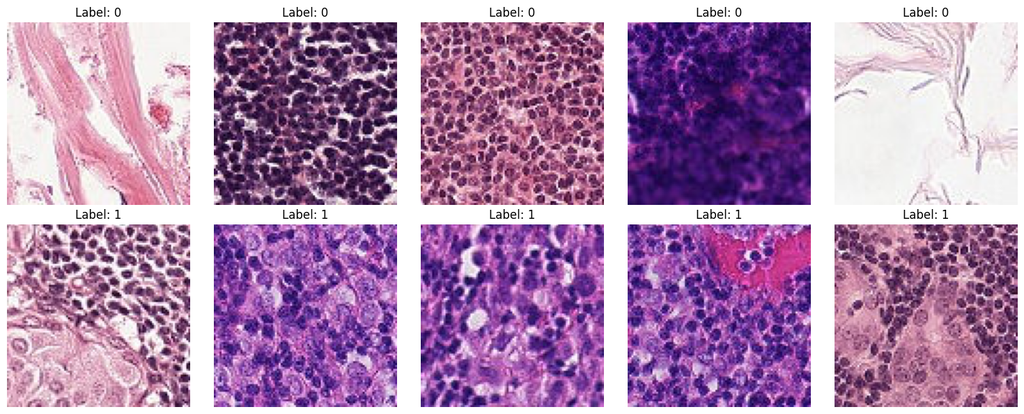

```python
# Sample some images from each class
def visualize_samples(n_samples=5):
    fig, axes = plt.subplots(2, n_samples, figsize=(15, 6))

    for label in [0, 1]:
        sample_df = train_labels[train_labels['label'] == label].sample(n_samples)

        for i, (_, row) in enumerate(sample_df.iterrows()):
            img = Image.open(row['path'])

            axes[label, i].imshow(img)
            axes[label, i].set_title("Label: %s" % label)
            axes[label, i].axis('off')

    plt.tight_layout()
    plt.show()

visualize_samples()
```

```python
def analyze_pixel_intensities(df, sample_size=1000):
    """Analyze pixel intensity distributions for each class"""
    np.random.seed(42)

    # Sample images from each class
    samples_0 = df[df['label'] == 0].sample(sample_size // 2)
    samples_1 = df[df['label'] == 1].sample(sample_size // 2)

    pixels_0 = []
    pixels_1 = []

    # Process negative samples
    for _, row in tqdm(samples_0.iterrows(), desc="Processing negative samples"):
        img = Image.open(row['path'])
        img_array = np.array(img)
        pixels_0.extend(img_array.flatten())

    # Process positive samples
    for _, row in tqdm(samples_1.iterrows(), desc="Processing positive samples"):
        img = Image.open(row['path'])
        img_array = np.array(img)
        pixels_1.extend(img_array.flatten())

    return pixels_0, pixels_1

# Analyze pixel intensities
pixels_0, pixels_1 = analyze_pixel_intensities(train_labels, sample_size=1000)
```

```
Processing negative samples: 500it [00:01, 489.64it/s]
Processing positive samples: 500it [00:01, 453.75it/s]
```

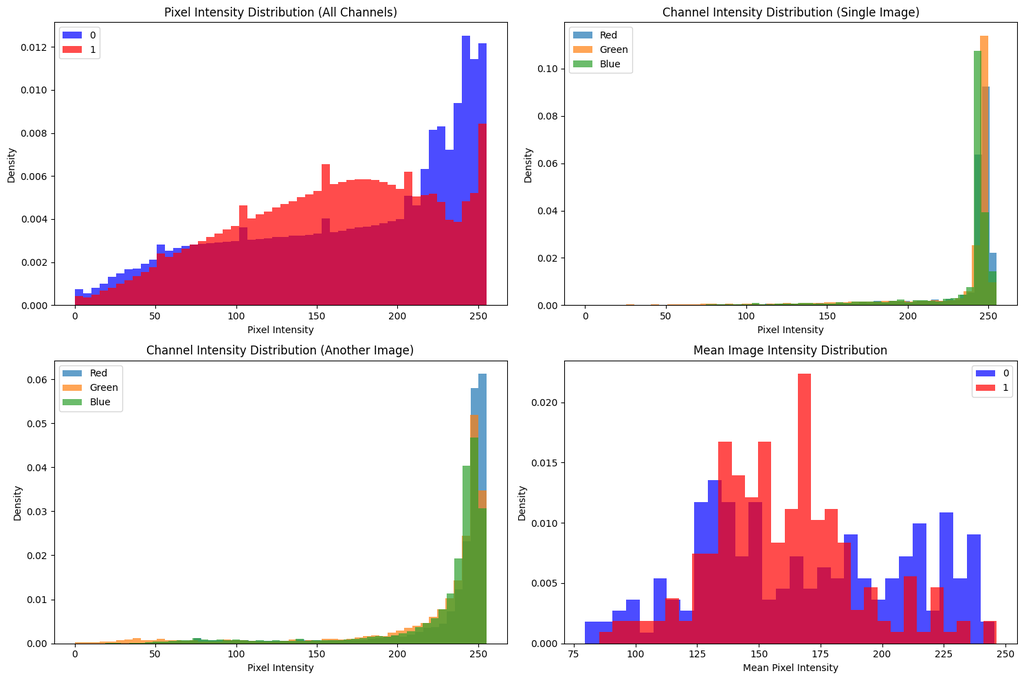

```python
# Plot pixel intensity histograms
plt.figure(figsize=(15, 10))

plt.subplot(2, 2, 1)
plt.hist(pixels_0, bins=50, alpha=0.7, label='0', color='blue', density=True)
plt.hist(pixels_1, bins=50, alpha=0.7, label='1', color='red', density=True)
plt.title('Pixel Intensity Distribution (All Channels)')
plt.xlabel('Pixel Intensity')
plt.ylabel('Density')
plt.legend()

plt.subplot(2, 2, 2)
# Sample a smaller subset for individual channels
sample_img = Image.open(train_labels.iloc[0]['path'])
sample_array = np.array(sample_img)
for i, color in enumerate(['Red', 'Green', 'Blue']):
    plt.hist(sample_array[:, :, i].flatten(), bins=50, alpha=0.7, label=color, density=True)
plt.title('Channel Intensity Distribution (Single Image)')
plt.xlabel('Pixel Intensity')
plt.ylabel('Density')
plt.legend()

plt.subplot(2, 2, 3)
# Sample a smaller subset for individual channels
sample_img = Image.open(train_labels.iloc[1]['path'])
sample_array = np.array(sample_img)
for i, color in enumerate(['Red', 'Green', 'Blue']):
    plt.hist(sample_array[:, :, i].flatten(), bins=50, alpha=0.7, label=color, density=True)
plt.title('Channel Intensity Distribution (Another Image)')
plt.xlabel('Pixel Intensity')
plt.ylabel('Density')
plt.legend()

plt.subplot(2, 2, 4)
# Compare mean intensities
means_0 = []
means_1 = []

for i in tqdm(range(200)):  # Smaller sample for performance
    neg_img = Image.open(train_labels[train_labels['label'] == 0].iloc[i]['path'])
    pos_img = Image.open(train_labels[train_labels['label'] == 1].iloc[i]['path'])

    means_0.append(np.mean(np.array(neg_img)))
    means_1.append(np.mean(np.array(pos_img)))

plt.hist(means_0, bins=30, alpha=0.7, label='0', color='blue', density=True)
plt.hist(means_1, bins=30, alpha=0.7, label='1', color='red', density=True)
plt.title('Mean Image Intensity Distribution')
plt.xlabel('Mean Pixel Intensity')
plt.ylabel('Density')
plt.legend()

plt.tight_layout()
plt.show()
```

## Data cleaning and processing

The data seems clean. The formats and dimensions are consistent across the dataset, and there are no missing or duplicate IDs between the two sets.

But some processing is still required. The most important steps are:

1. Notice that the distribution of the training and test samples is not equal. Whereever possible, try to take an equal number of samples from each to produce a balanced model while training.
2. The value in each pixel ranges from 0 to 255. To get faster and better training, rescale to a range of 0 to 1.
3. Add some modifications to the training dataset - rotations, shifts, flips and zooms. This helps increase the adaptability of the trained model.
4. Note that another label column with a value type of string was created, as this allows the model to be specified as binary.

From the inspection of the images, it can be persumed that the colour information will be important in the analyses. The colours were therefore kept as is.

```python
# Convert labels to strings for the generator
train_labels['label_str'] = train_labels['label'].astype(str)

# Prepare a subset for hyperparameter tuning
tuning_subset = pd.concat([
    train_labels[train_labels['label'] == 0].sample(5000, random_state=42),
    train_labels[train_labels['label'] == 1].sample(5000, random_state=42)
])

# Split into train and validation
train_df, val_df = train_test_split(
    tuning_subset,
    test_size=0.2,
    stratify=tuning_subset['label'],
    random_state=42
)
```

```python
# Prepare data generators - use class_mode='binary' with string labels
datagen = ImageDataGenerator(
    rescale=1./255,
    rotation_range=20,
    width_shift_range=0.1,
    height_shift_range=0.1,
    horizontal_flip=True,
    vertical_flip=True,
    zoom_range=0.1
)

# Create data generators using the path column and string labels
train_generator = datagen.flow_from_dataframe(
    dataframe=train_df,
    x_col='path',
    y_col='label_str',
    target_size=(IMG_SIZE, IMG_SIZE),
    batch_size=BATCH_SIZE,
    class_mode='binary'
)

val_generator = datagen.flow_from_dataframe(
    dataframe=val_df,
    x_col='path',
    y_col='label_str',
    target_size=(IMG_SIZE, IMG_SIZE),
    batch_size=BATCH_SIZE,
    class_mode='binary',
    shuffle=False
)
```

```
Found 8000 validated image filenames belonging to 2 classes.
Found 2000 validated image filenames belonging to 2 classes.
```

## Model architecture

Based on the complexity of the data, I believe a deep/wide architecture would be more effective than a simpler one. In order to be sure however, I created a function flexible enough to allow the testing of different architectures and regularization methods.

### Plan of attack

First of all, three architectures will be tested: simple, deeper, and wider.

The best performing of these three will have its regularization tuned and used for submission.

For architecture selection and regularization tuning, a smaller dataset and number of epochs will be used to make the process faster. Once a combination is chosen, it will be trained on the bigger dataset before submission.

### Techniques used to improve the training

So as not to have to retrain the models each time the notebook was re-run, I decided to use the callback ModelCheckpoint. The callback would save the best-performing model on-disk and reload it as needed.

This approach had another pleasant effect. Previously, the fluctuations in the validation scores meant that a fair comparison between the different models was impractical. However, by choosing the best performing epoch of each model, a much more fair comparison was possible, and it worked splendidly.

```python
# Single flexible function to create CNN models with different architectures and regularization
def create_cnn_model(architecture='deeper', regularization=None, reg_strength=.001,
                     dropout_rate=.5, additional_dropout=False, additional_bn=False):
    """
    Create a CNN model with specified architecture and regularization.

    Parameters:
    - architecture: 'simple', 'deeper', or 'wider'
    - regularization: None, 'l1', 'l2', 'l1_l2'
    - reg_strength: regularization strength
    - dropout_rate: dropout rate for dense layers
    - additional_dropout: whether to add dropout after convolutional layers
    - additional_bn: whether to add additional batch normalization layers

    Returns:
    - Compiled Keras model
    """

    # Define regularization function
    if regularization == 'l1':
        reg = l1(reg_strength)
    elif regularization == 'l2':
        reg = l2(reg_strength)
    elif regularization == 'l1_l2':
        reg = l1_l2(l1=reg_strength/2, l2=reg_strength/2)
    else:  # 'none'
        reg = None

    # Define architecture parameters
    if architecture == 'simple':
        conv_layers = [
            (32, 3),  # (filters, kernel_size)
            (64, 3)
        ]
        dense_units = 64
    elif architecture == 'deeper':
        conv_layers = [
            (32, 3),
            (64, 3),
            (128, 3)
        ]
        dense_units = 128
    elif architecture == 'wider':
        conv_layers = [
            (64, 3),
            (128, 3),
            (256, 3)
        ]
        dense_units = 256
    else:
        raise ValueError("Architecture must be 'simple', 'deeper', or 'wider'")

    # Build the model
    model = Sequential()

    # Input layer
    model.add(Conv2D(conv_layers[0][0], (conv_layers[0][1], conv_layers[0][1]),
                    activation='relu', input_shape=(IMG_SIZE, IMG_SIZE, 3),
                    kernel_regularizer=reg))
    model.add(BatchNormalization())
    model.add(MaxPooling2D((2, 2)))

    if additional_dropout:
        model.add(Dropout(0.2))
    if additional_bn:
        model.add(BatchNormalization())

    # Additional convolutional layers
    for filters, kernel_size in conv_layers[1:]:
        model.add(Conv2D(filters, (kernel_size, kernel_size),
                        activation='relu', kernel_regularizer=reg))
        model.add(BatchNormalization())
        model.add(MaxPooling2D((2, 2)))

        if additional_dropout:
            model.add(Dropout(0.2))
        if additional_bn:
            model.add(BatchNormalization())

    # Dense layers
    model.add(Flatten())
    model.add(Dense(dense_units, activation='relu', kernel_regularizer=reg))

    if additional_bn:
        model.add(BatchNormalization())

    model.add(Dropout(dropout_rate))
    model.add(Dense(1, activation='sigmoid'))

    # Compile the model
    model.compile(optimizer='adam',
                  loss='binary_crossentropy',
                  metrics=['accuracy', tf.keras.metrics.AUC(name='auc')])

    return model
```

```python
# Test different model architectures
arch_models = [
    {
        "name": "Simple CNN",
        "params": { 'architecture': 'simple', },
    },
    {
        "name": "Deeper CNN",
        "params": { 'architecture': 'deeper', },
    },
    {
        "name": "Wider CNN",
        "params": { 'architecture': 'wider', },
    },
]

# Create directories for checkpoints and histories
os.makedirs("checkpoints", exist_ok=True)
os.makedirs("histories", exist_ok=True)

for model in arch_models:
    model["checkpoint"] = os.path.join("checkpoints", "%s.keras" % model["name"])
    model["history_file"] = os.path.join("histories", "%s.csv" % model["name"])
```

# Train each model architecture # This cell can be left without running if the checkpoint files are available for model in arch_models: print("\nTraining %s..." % model["name"]) model_instance = create_cnn_model(**model["params"]) # Callbacks early_stopping = EarlyStopping(monitor='val_auc', patience=5, restore_best_weights=True, mode='max') reduce_lr = ReduceLROnPlateau(monitor='val_auc', factor=.5, patience=3, min_lr=1e-7, mode='max') model_checkpoint = ModelCheckpoint(model["checkpoint"], save_best_only=True, monitor='val_auc', mode='max') hist_logger = CSVLogger(model["history_file"]) # Reset generators to ensure consistent training across models train_generator.reset() val_generator.reset() model_instance.fit( train_generator, epochs=15, # Fewer epochs for tuning validation_data=val_generator, callbacks=[early_stopping, reduce_lr, model_checkpoint, hist_logger], verbose=1 )

```python
# Load and evaluate each model
for model in arch_models:
    model["instance"] = load_model(model["checkpoint"])

    # Evaluate the model
    val_generator.reset()
    val_preds = model["instance"].predict(val_generator)
    model["auc"] = roc_auc_score(val_generator.classes, val_preds)

    model["history"] = pd.read_csv(model["history_file"], sep=',', engine='python')

    print("%s Validation AUC: %.4f" % (model["name"], model["auc"]))

arch_models_df = pd.DataFrame(arch_models)
```

[output not shown]

```
 3/32 ━━━━━━━━━━━━━━━━━━━━ 1s 60ms/step
```

```
I0000 00:00:1757490266.659969 1673357 device_compiler.h:196] Compiled cluster using XLA!  This line is logged at most once for the lifetime of the process.
```

```
31/32 ━━━━━━━━━━━━━━━━━━━━ 0s 110ms/step
```

[output not shown]

```
32/32 ━━━━━━━━━━━━━━━━━━━━ 5s 124ms/step
Simple CNN Validation AUC: 0.9180
```

[output not shown]

```
31/32 ━━━━━━━━━━━━━━━━━━━━ 0s 114ms/step
```

[output not shown]

```
32/32 ━━━━━━━━━━━━━━━━━━━━ 5s 128ms/step
Deeper CNN Validation AUC: 0.9331
```

[output not shown]

```
31/32 ━━━━━━━━━━━━━━━━━━━━ 0s 112ms/step
```

[output not shown]

```
32/32 ━━━━━━━━━━━━━━━━━━━━ 6s 134ms/step
Wider CNN Validation AUC: 0.9239
```

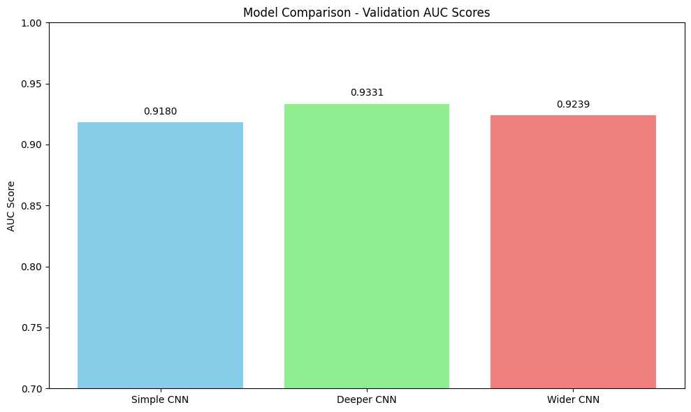

```python
# Compare model performance
plt.figure(figsize=(10, 6))

bars = plt.bar(arch_models_df["name"], arch_models_df["auc"], color=['skyblue', 'lightgreen', 'lightcoral'])
plt.title('Model Comparison - Validation AUC Scores')
plt.ylabel('AUC Score')
plt.ylim(.7, 1.0)

# Add value labels on bars
for bar, score in zip(bars, arch_models_df["auc"]):
    plt.text(bar.get_x() + bar.get_width()/2, bar.get_height() + .005,
             '%.4f' % score, ha='center', va='bottom')

plt.tight_layout()
plt.show()
```

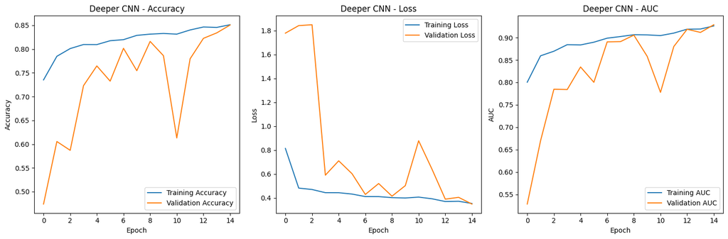

```python
# Plot training history for the best model
arch_best_model = arch_models[arch_models_df.auc.idxmax()]

plt.figure(figsize=(15, 5))

plt.subplot(1, 3, 1)
plt.plot(arch_best_model['history']['accuracy'], label='Training Accuracy')
plt.plot(arch_best_model['history']['val_accuracy'], label='Validation Accuracy')
plt.title('%s - Accuracy' % arch_best_model["name"])
plt.xlabel('Epoch')
plt.ylabel('Accuracy')
plt.legend()

plt.subplot(1, 3, 2)
plt.plot(arch_best_model['history']['loss'], label='Training Loss')
plt.plot(arch_best_model['history']['val_loss'], label='Validation Loss')
plt.title('%s - Loss' % arch_best_model["name"])
plt.xlabel('Epoch')
plt.ylabel('Loss')
plt.legend()

plt.subplot(1, 3, 3)
plt.plot(arch_best_model['history']['auc'], label='Training AUC')
plt.plot(arch_best_model['history']['val_auc'], label='Validation AUC')
plt.title('%s - AUC' % arch_best_model["name"])
plt.xlabel('Epoch')
plt.ylabel('AUC')
plt.legend()

plt.tight_layout()
plt.show()
```

```python
# Test different regularization methods on the best architecture
best_architecture = arch_best_model["params"]["architecture"]

reg_models = [
    {
        "name": "Original (No Reg)",
        "params": {'architecture': best_architecture, 'regularization': None}
    },
    {
        "name": "L2 Regularization",
        "params": {'architecture': best_architecture, 'regularization': 'l2', 'reg_strength': 0.001}
    },
    {
        "name": "L1 Regularization",
        "params": {'architecture': best_architecture, 'regularization': 'l1', 'reg_strength': 0.001}
    },
    {
        "name": "Elastic Net (L1+L2)",
        "params": {'architecture': best_architecture, 'regularization': 'l1_l2', 'reg_strength': 0.001}
    },
    {
        "name": "Increased Dropout",
        "params": {'architecture': best_architecture, 'regularization': None,
                  'dropout_rate': 0.6, 'additional_dropout': True}
    },
    {
        "name": "Additional BatchNorm",
        "params": {'architecture': best_architecture, 'regularization': None,
                  'additional_bn': True}
    }
]

# Create checkpoints and history files for each regularization model
for model in reg_models:
    model["checkpoint"] = os.path.join("checkpoints", "%s %s.keras" % (best_architecture, model["name"]))
    model["history_file"] = os.path.join("histories", "%s %s.csv" % (best_architecture, model["name"]))
```

# Train each regularization model # This cell can be left without running if the checkpoint files are available for model in reg_models: print("\nTraining %s..." % model["name"]) model_instance = create_cnn_model(**model["params"]) # Callbacks early_stopping = EarlyStopping(monitor='val_auc', patience=5, restore_best_weights=True, mode='max') reduce_lr = ReduceLROnPlateau(monitor='val_auc', factor=.5, patience=3, min_lr=1e-7, mode='max') model_checkpoint = ModelCheckpoint(model["checkpoint"], save_best_only=True, monitor='val_auc', mode='max') hist_logger = CSVLogger(model["history_file"]) # Reset generators to ensure consistent training train_generator.reset() val_generator.reset() model_instance.fit( train_generator, epochs=15, validation_data=val_generator, callbacks=[early_stopping, reduce_lr, model_checkpoint, hist_logger], verbose=1 )

```python
# Load and evaluate each regularization model
for model in reg_models:
    model["instance"] = load_model(model["checkpoint"])

    # Evaluate the model
    val_generator.reset()
    val_preds = model["instance"].predict(val_generator)
    model["auc"] = roc_auc_score(val_generator.classes, val_preds)

    model["history"] = pd.read_csv(model["history_file"], sep=',', engine='python')

    print("%s Validation AUC: %.4f" % (model["name"], model["auc"]))

reg_models_df = pd.DataFrame(reg_models)
```

```
32/32 ━━━━━━━━━━━━━━━━━━━━ 4s 122ms/step
Original (No Reg) Validation AUC: 0.9258
32/32 ━━━━━━━━━━━━━━━━━━━━ 4s 118ms/step
L2 Regularization Validation AUC: 0.9247
32/32 ━━━━━━━━━━━━━━━━━━━━ 5s 129ms/step
L1 Regularization Validation AUC: 0.9083
32/32 ━━━━━━━━━━━━━━━━━━━━ 5s 127ms/step
Elastic Net (L1+L2) Validation AUC: 0.9103
32/32 ━━━━━━━━━━━━━━━━━━━━ 4s 121ms/step
Increased Dropout Validation AUC: 0.9122
32/32 ━━━━━━━━━━━━━━━━━━━━ 4s 123ms/step
Additional BatchNorm Validation AUC: 0.9327
```

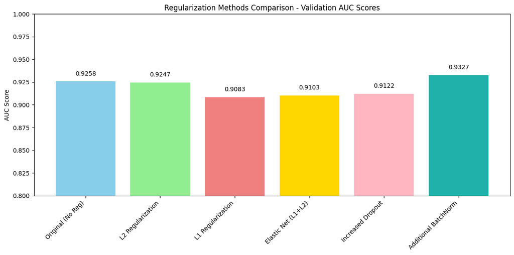

```
Best regularization method: Additional BatchNorm with AUC: 0.9327
```

```python
# Compare regularization methods
plt.figure(figsize=(12, 6))

bars = plt.bar(reg_models_df["name"], reg_models_df["auc"],
               color=['skyblue', 'lightgreen', 'lightcoral', 'gold', 'lightpink', 'lightseagreen'])
plt.title('Regularization Methods Comparison - Validation AUC Scores')
plt.ylabel('AUC Score')
plt.xticks(rotation=45, ha='right')
plt.ylim(0.8, 1.0)

# Add value labels on bars
for bar, score in zip(bars, reg_models_df["auc"]):
    plt.text(bar.get_x() + bar.get_width()/2, bar.get_height() + 0.005,
             '%.4f' % score, ha='center', va='bottom')

plt.tight_layout()
plt.show()

# Find the best regularization method
best_reg_model = reg_models[reg_models_df.auc.idxmax()]
best_reg_method = best_reg_model["name"]

print("\nBest regularization method: %s with AUC: %.4f" % (best_reg_method, best_reg_model['auc']))
```

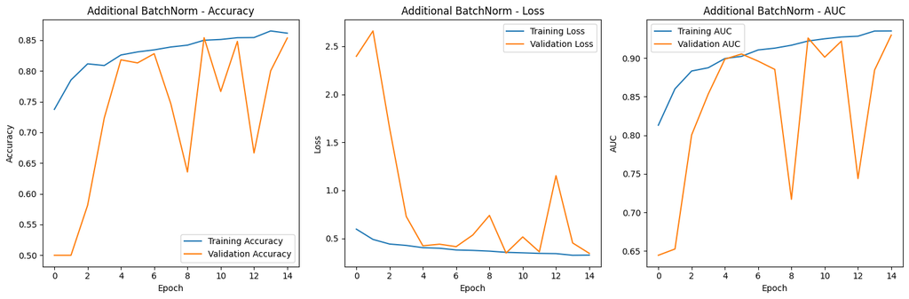

```python
# Plot training curves for the best regularization method
plt.figure(figsize=(15, 5))

plt.subplot(1, 3, 1)
plt.plot(best_reg_model['history']['accuracy'], label='Training Accuracy')
plt.plot(best_reg_model['history']['val_accuracy'], label='Validation Accuracy')
plt.title('%s - Accuracy' % best_reg_model["name"])
plt.xlabel('Epoch')
plt.ylabel('Accuracy')
plt.legend()

plt.subplot(1, 3, 2)
plt.plot(best_reg_model['history']['loss'], label='Training Loss')
plt.plot(best_reg_model['history']['val_loss'], label='Validation Loss')
plt.title('%s - Loss' % best_reg_model["name"])
plt.xlabel('Epoch')
plt.ylabel('Loss')
plt.legend()

plt.subplot(1, 3, 3)
plt.plot(best_reg_model['history']['auc'], label='Training AUC')
plt.plot(best_reg_model['history']['val_auc'], label='Validation AUC')
plt.title('%s - AUC' % best_reg_model["name"])
plt.xlabel('Epoch')
plt.ylabel('AUC')
plt.legend()

plt.tight_layout()
plt.show()
```

```python
# Train the best regularized model on the full dataset
print("\nTraining the best regularized model (%s) on the full dataset..." % best_reg_method)

# Prepare full data generators
full_datagen = ImageDataGenerator(
    rescale=1./255,
    validation_split=0.2,
    rotation_range=20,
    width_shift_range=0.1,
    height_shift_range=0.1,
    horizontal_flip=True,
    vertical_flip=True,
    zoom_range=0.1
)

full_train_generator = full_datagen.flow_from_dataframe(
    dataframe=train_labels,
    x_col='path',
    y_col='label_str',
    target_size=(IMG_SIZE, IMG_SIZE),
    batch_size=BATCH_SIZE,
    class_mode='binary',
    subset='training'
)

full_val_generator = full_datagen.flow_from_dataframe(
    dataframe=train_labels,
    x_col='path',
    y_col='label_str',
    target_size=(IMG_SIZE, IMG_SIZE),
    batch_size=BATCH_SIZE,
    class_mode='binary',
    subset='validation',
    shuffle=False
)

# Add callbacks for final training
final_checkpoint = ModelCheckpoint("final_model.keras", save_best_only=True, monitor='val_auc', mode='max')
final_csv_logger = CSVLogger("final_training_history.csv")
```

```
Training the best regularized model (Additional BatchNorm) on the full dataset...
Found 176020 validated image filenames belonging to 2 classes.
Found 44005 validated image filenames belonging to 2 classes.
```

# This cell can be left without running if the checkpoint files are available # Create the best regularized model final_model = create_cnn_model(**best_reg_model["params"]) # Train the final model final_model.fit( full_train_generator, epochs=EPOCHS, validation_data=full_val_generator, callbacks=[early_stopping, reduce_lr, final_checkpoint, final_csv_logger], verbose=1 )

```python
# Load the best model from checkpoint
final_model = load_model("final_model.keras")
final_history = pd.read_csv("final_training_history.csv", sep=',', engine='python')

# Evaluate the final model
final_val_preds = final_model.predict(full_val_generator)
final_val_labels = full_val_generator.classes

final_val_pred_classes = (final_val_preds > 0.5).astype(int).flatten()
final_val_auc = roc_auc_score(final_val_labels, final_val_preds)

print("Final Model Validation AUC: %.4f" % final_val_auc)
print("\nClassification Report:")
print(classification_report(final_val_labels, final_val_pred_classes))
```

```
687/688 ━━━━━━━━━━━━━━━━━━━━ 0s 130ms/step
```

[output not shown]

```
688/688 ━━━━━━━━━━━━━━━━━━━━ 91s 131ms/step
Final Model Validation AUC: 0.9878

Classification Report:
              precision    recall  f1-score   support

           0       0.95      0.97      0.96     26233
           1       0.95      0.93      0.94     17772

    accuracy                           0.95     44005
   macro avg       0.95      0.95      0.95     44005
weighted avg       0.95      0.95      0.95     44005
```

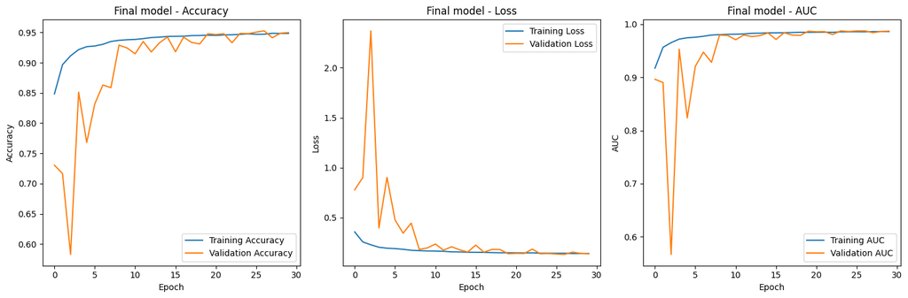

```python
# Plot training curves for the best regularization method
plt.figure(figsize=(15, 5))

plt.subplot(1, 3, 1)
plt.plot(final_history['accuracy'], label='Training Accuracy')
plt.plot(final_history['val_accuracy'], label='Validation Accuracy')
plt.title('Final model - Accuracy')
plt.xlabel('Epoch')
plt.ylabel('Accuracy')
plt.legend()

plt.subplot(1, 3, 2)
plt.plot(final_history['loss'], label='Training Loss')
plt.plot(final_history['val_loss'], label='Validation Loss')
plt.title('Final model - Loss')
plt.xlabel('Epoch')
plt.ylabel('Loss')
plt.legend()

plt.subplot(1, 3, 3)
plt.plot(final_history['auc'], label='Training AUC')
plt.plot(final_history['val_auc'], label='Validation AUC')
plt.title('Final model - AUC')
plt.xlabel('Epoch')
plt.ylabel('AUC')
plt.legend()

plt.tight_layout()
plt.show()
```

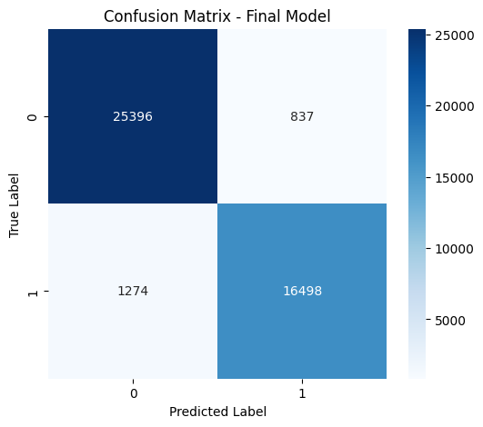

```python
# Confusion matrix
cm = confusion_matrix(final_val_labels, final_val_pred_classes)
plt.figure(figsize=(6, 5))
sns.heatmap(cm, annot=True, fmt='d', cmap='Blues')
plt.title('Confusion Matrix - Final Model')
plt.ylabel('True Label')
plt.xlabel('Predicted Label')
plt.show()
```

```python
# Prepare test data for prediction
test_files = os.listdir(TEST_DIR)
test_ids = [os.path.splitext(f)[0] for f in test_files]
test_paths = [os.path.join(TEST_DIR, f) for f in test_files]

test_df = pd.DataFrame({
    'id': test_ids,
    'path': test_paths
})

test_datagen = ImageDataGenerator(rescale=1./255)

test_generator = test_datagen.flow_from_dataframe(
    dataframe=test_df,
    x_col='path',
    y_col=None,
    target_size=(IMG_SIZE, IMG_SIZE),
    batch_size=BATCH_SIZE,
    class_mode=None,
    shuffle=False
)
```

```
Found 57458 validated image filenames.
```

```python
# Make predictions on test set
test_preds = final_model.predict(test_generator)
```

```
896/898 ━━━━━━━━━━━━━━━━━━━━ 0s 45ms/step
```

[output not shown]

```
898/898 ━━━━━━━━━━━━━━━━━━━━ 42s 46ms/step
```

```python
# Create submission file
submission = pd.DataFrame({
    'id': test_ids,
    'label': test_preds.flatten()
})

submission.to_csv('submission.csv', index=False)
print("Submission file created successfully!")
```

```
Submission file created successfully!
```

## Conclusion

From the hyperparameter tuning figures, it seems that additional batch normalization improved the validation performance, but only by 1%. Overall, almost all the hyperparameter settings produced the same result. The same goes for the architecture setting, as deeper only won by a tiny margin.

What helped the most in getting the performance up was using ModelCheckpoint, as it helped smooth out the problem of fluctuations especially in the model selection part.

The large fluctuation in the validation scores remain a huge concern nevertheless. It is true that for our case we can filter out the epoch which produced the best performance, but there is no guarantee that the batch which scored the best AUC on our validation set would also score well on Kaggle's test set.

On inspecting the training logs on the larger dataset, it seems that the fluctuations are much less on the larger dataset especially as the number of epochs increased. Could it be that the fluctuation was caused by the limited dataset size and number of epochs used while choosing the model and hypertuning?

Further improvements one could make would be investigating that issue further. Another point of research would be investigating whether aggressive regularization helps smoothen out the fluctuations as well.